# Comparing agentic RNA-seq analyses across branches

One airway dataset, ten agentic analyses — how they converged, where they diverged, and how correct they were

Published

September 7, 2026

# 1 Overview

Every `demo/*` branch of this repository is an **independent agentic analysis of the same dataset** — the *airway* experiment (Himes et al. 2014): human airway smooth-muscle cells from four donors, each sequenced untreated and dexamethasone-treated, quantified with RSEM (~58,735 genes × 8 samples). Each branch was produced by a different person driving an AI coding agent toward the same goal: **differential expression, Dexamethasone vs Untreated.**

This report compares **ten** of those branches (all except `yangz`, which is data-only) across the three artefacts the agents produced — the **`CLAUDE.md`** context file, the **analysis script**, and the **results** — and assesses **how correct** each analysis was against an independent, published reference.

**Method in one paragraph**

We re-ran every branch we could from source (R/DESeq2 via `knitr::purl`; PyDESeq2 in a Python 3.12 env; clawbio branches from their committed output, since the clawbio engine was not available here), harmonized each DE table to a common schema, and scored them against a **gold-standard reference**: the canonical DESeq2 workflow on the *published* Bioconductor `airway` package (`~ cell + dex`, Untreated reference, apeglm shrinkage) — deliberately a *different* quantification than this repo’s RSEM matrix, so concordance is judged on **rank, overlap, direction and marker recovery** rather than absolute fold-change. All numbers below are computed by the harness in `analysis/harness/` and read from `analysis/data/`.

## 1.1 Execution status

Eight branches were re-executed end-to-end; `barretj` is compared from its committed clawbio output; `davidlvb` is assessed from source only (its clawbio engine could not be regenerated here and it committed no results).

[output not shown]

# 2 Layer 1 — the `CLAUDE.md` context files

The `CLAUDE.md` is the context each agent was given (or wrote) about the dataset. We scored each against a fixed **16-point rubric** of correct, analysis-critical facts, by objective keyword presence.

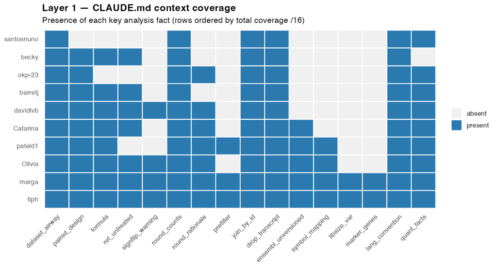

Figure 1: Coverage of each key analysis fact across the ten CLAUDE.md files (rows ordered by total coverage).

**Consensus.** Ten out of ten correctly identify the dataset, state the analysis language/deliverable convention, note that the two files join on sample **ID** (not position), and flag that the `transcript_id(s)` column must be dropped. The paired design and the `~ cellLine + treatment` formula are near-universal (9/10 and 8/10).

**Divergence.** The files split sharply on the *measured* details that separate a generic dataset description from an analysis-ready brief:

- **Pre-filtering** is mentioned by only **3/10** (tiph, pateld1, marga).
- **Marker genes** for a biological sanity check and **library-size variation** appear in only **2/10** (tiph, marga).
- The **sign-flip risk** from R’s alphabetical factor default is warned about in **4/10**.

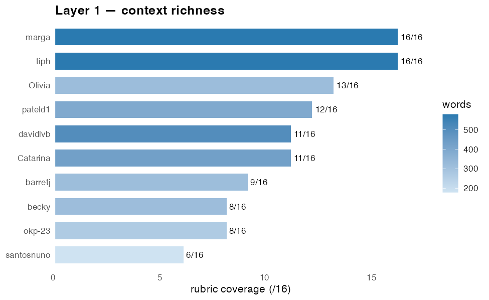

Figure 2: Context richness: rubric coverage (bars) and word count (fill). tiph and marga lead at 16/16; santosnuno is leanest at 6/16.

**Accuracy.** Every quantitative claim we could check was **correct**: the branches that cite measured numbers (tiph, marga, pateld1) state 58,735 genes, 28,344 all-zero (48.3%), 11,117 non-integer rows, and 14.9–30.3 M library sizes — all verified exactly against the data. No `CLAUDE.md` contained a false statement; the differences are of **depth, not accuracy**. The files that “measured the data” (tiph, marga, pateld1) produced richer briefs — but, as Layer 2 shows, the leaner briefs still yielded correct analyses, because the omitted facts (round, filter, reference level) are also DESeq2 standard practice and were applied in code regardless.

# 3 Layer 2 — the analysis scripts

[output not shown]

**The consensus recipe.** Independently, all ten converged on the *same* statistically-correct pipeline:

1. **Design `~ cellLine + treatment`** — the paired/blocked design, in every branch. None fell into the “4-vs-4 unpaired” trap that was flagged as the most likely mistake.
2. **`Untreated` as reference** — set explicitly everywhere (via `relevel`, explicit factor levels, category reorder, or clawbio’s contrast direction), so a positive LFC = induced.
3. **Round RSEM counts to integers** before modelling.
4. **Low-count pre-filter**, then **apeglm/clawbio LFC shrinkage**, **BH-adjusted** p-values at **padj < 0.05**, and **VST** for PCA/clustering.
5. **The full diagnostic suite** — PCA, volcano, MA, sample-distance, and expression heatmaps appear in nearly every branch.

**Where they diverged (all defensible):**

- **Engine.** Seven used **R/DESeq2**; `pateld1` used **PyDESeq2**; `barretj` and `davidlvb` used the **clawbio** skill (a PyDESeq2 wrapper). This is the single biggest split and the one visible in the outputs (Layer 3).
- **Low-count filter.** Total-count ≥ 10 (Catarina, marga, okp-23, pateld1) vs ≥ 10 in ≥ 4 samples (Olivia, santosnuno, becky, tiph) vs ≥ 10 in ≥ 2 (davidlvb) vs clawbio’s default (barretj). This changes *genes tested* substantially but *significant genes* barely (Layer 3).
- **Symbol mapping.** All but **becky** map Ensembl IDs to symbols (becky stays in Ensembl IDs).
- **Scope & polish.** `davidlvb` alone adds **pathway enrichment**; `okp-23` ships **reusable skills with unit tests**; `pateld1` adds a **paired-vs-unpaired sensitivity check** and assertion guards; `barretj` ships a **full reproducibility bundle**; `tiph`/`marga` invest in report styling.

**Correctness review.** Reading every script, we found **no correctness-breaking bug**: no dropped blocking factor, no mis-set reference, no `floor()`/truncation of counts. Two branches show notable defensive engineering — `pateld1` encodes every consistency check as a runtime assertion (and handles the PyDESeq2 0.5.x reference-level API), and `tiph` degrades gracefully from apeglm to `normal` shrinkage if apeglm is absent. `davidlvb` documents a real clawbio Enrichr bug and works around it with `gseapy`.

# 4 Layer 3 — the results

## 4.1 Genes tested vs significant

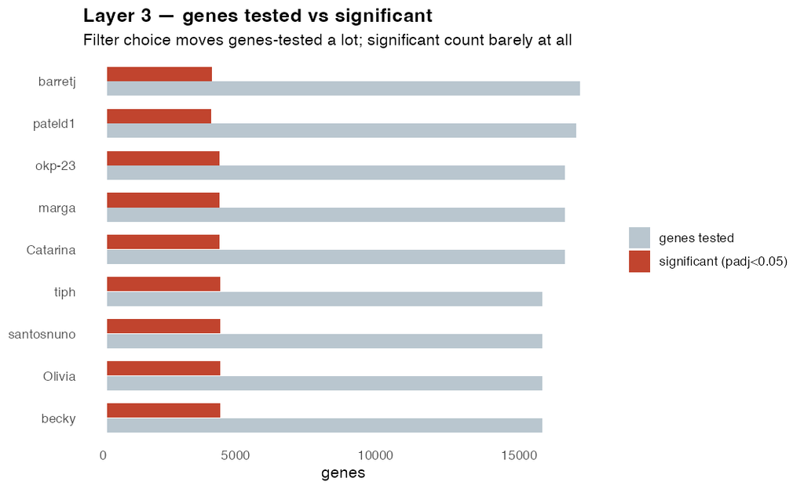

## 4.2 Cross-branch agreement

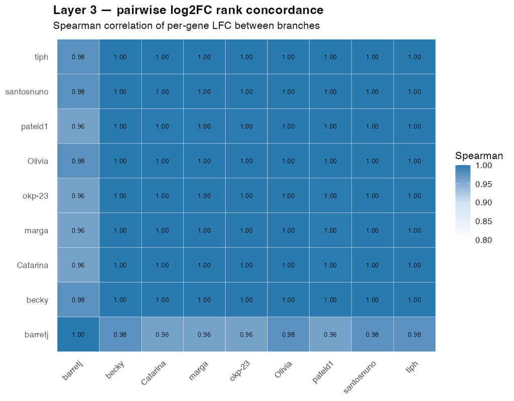

Figure 4: Pairwise Spearman correlation of per-gene log2FC. Median across all pairs = 1.00.

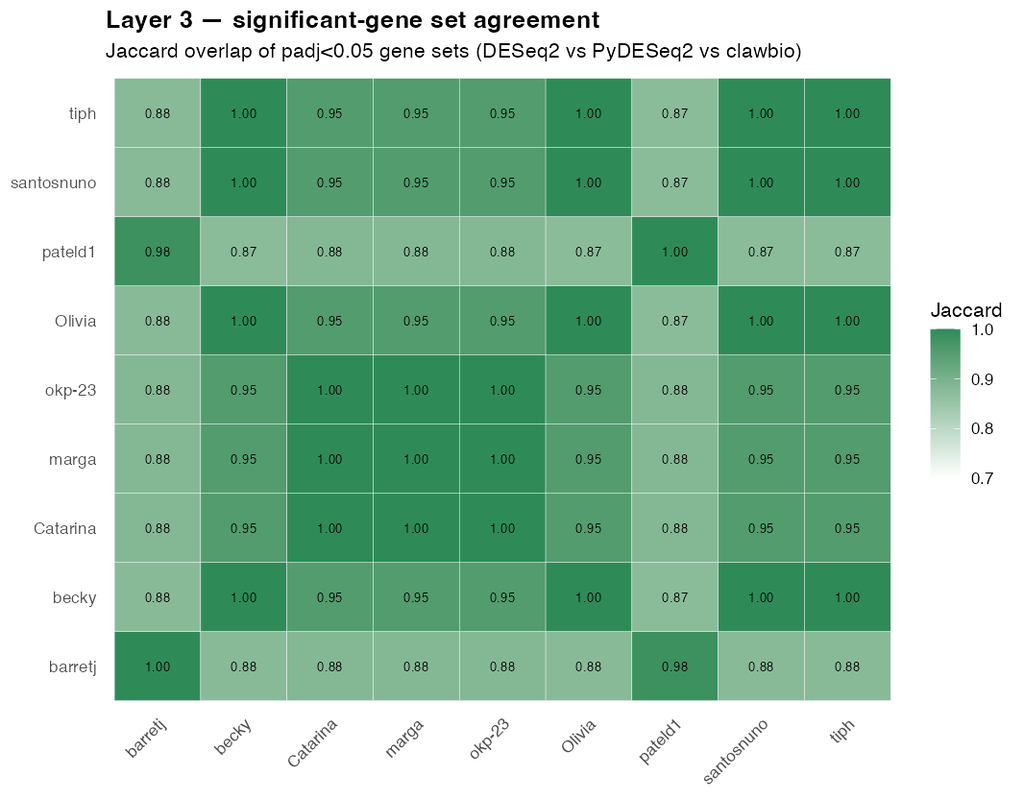

Figure 5: Pairwise Jaccard overlap of significant (padj<0.05) gene sets. Median = 0.955.

On the shared RSEM matrix the branches are **almost indistinguishable**: median pairwise Spearman LFC = **1.00**, median significant-set Jaccard = **0.955**. `barretj` (clawbio) is the only mild outlier (0.96–0.98), reflecting its different filter and engine. **3,491 genes are significant in *all* nine quantitatively-compared branches** — and **94% of that core set is also significant in the independent airway reference.**

## 4.3 Concordance with the published reference

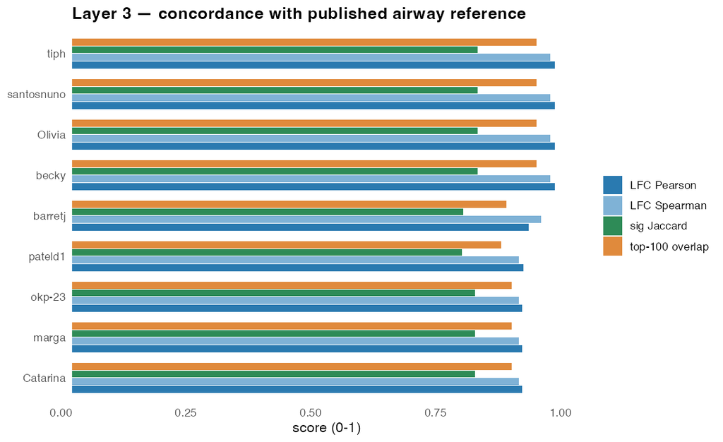

Figure 6: Each branch vs the published airway reference: log2FC correlation, top-100 overlap, and significant-set Jaccard.

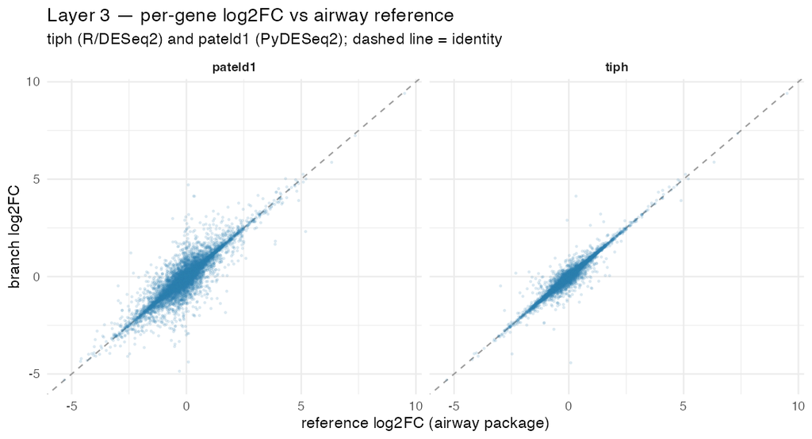

Figure 7: Per-gene log2FC vs the airway reference for a DESeq2 branch (tiph) and a PyDESeq2 branch (pateld1). Dashed line = identity.

[output not shown]

## 4.4 Biological validity

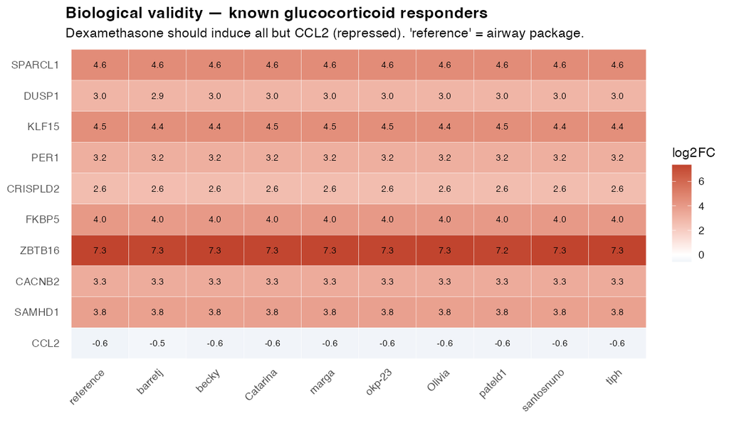

Figure 8: log2FC of known glucocorticoid-responsive genes. Every branch matches the reference: strong induction of SPARCL1/ZBTB16/KLF15/DUSP1/etc., and CCL2 repressed.

This is the strongest evidence that all agents recovered the **correct biology**: for the known responders, every branch reproduces the reference log2FC to within rounding (SPARCL1 ≈ 4.6, ZBTB16 ≈ 7.3, KLF15 ≈ 4.4, DUSP1 ≈ 3.0), and CCL2 is repressed everywhere. Direction agreement with the reference on co-significant genes is **100% in every branch**.

# 5 Correctness scorecard

Synthesising all layers into five explicit dimensions (each 0–1; composite = their mean). A/B come from the verified script matrix, C/D from computed metrics, E is a transparent reviewer rubric over committed reproducibility artefacts.

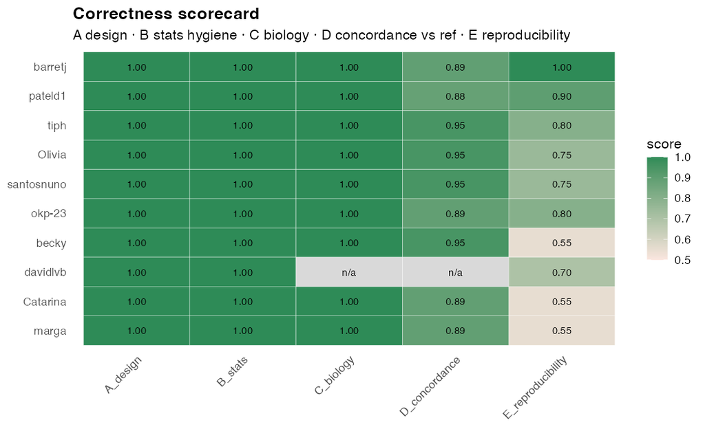

Figure 9: A: paired-design correctness · B: statistical hygiene · C: biological validity · D: concordance vs reference · E: reproducibility.

| branch | A_design | B_stats | C_biology | D_concordance | E_reproducibility | composite |
| --- | --- | --- | --- | --- | --- | --- |
| barretj | 1 | 1 | 1 | 0.892 | 1.00 | 0.978 |
| pateld1 | 1 | 1 | 1 | 0.882 | 0.90 | 0.956 |
| tiph | 1 | 1 | 1 | 0.949 | 0.80 | 0.950 |
| Olivia | 1 | 1 | 1 | 0.949 | 0.75 | 0.940 |
| santosnuno | 1 | 1 | 1 | 0.949 | 0.75 | 0.940 |
| okp-23 | 1 | 1 | 1 | 0.890 | 0.80 | 0.938 |
| becky | 1 | 1 | 1 | 0.949 | 0.55 | 0.900 |
| davidlvb | 1 | 1 | NA | NA | 0.70 | 0.900 |
| Catarina | 1 | 1 | 1 | 0.890 | 0.55 | 0.888 |
| marga | 1 | 1 | 1 | 0.890 | 0.55 | 0.888 |

**Every branch is statistically and biologically correct** (A, B, C at ceiling). Branches separate almost entirely on **reproducibility (E)** and marginally on **concordance (D)**. `barretj` leads on the strength of a full reproducibility bundle (checksums, pinned environment, replayable commands); `pateld1` follows (assertions, pinned requirements, seed); the tightly-filtered R branches (`tiph`, `Olivia`, `santosnuno`, `becky`) score highest on concordance. `davidlvb`’s C/D are `n/a` (its clawbio output could not be regenerated here); its method mirrors `barretj`.

# 6 Consensus vs divergence — the bottom line

**Consensus (what every agent got right).** Same dataset understanding, same paired design, same reference level, same core statistical recipe, and — most importantly — **the same answer**: a ~3,500-gene core DE set, recovered in every branch, 94% of it confirmed by an independent published reference, with all known glucocorticoid markers induced in the correct direction. The agentic analyses are **reproducible and correct**, and they agree with each other to a near-perfect degree.

**Divergence (where taste and tooling showed).** The differences are real but sit *above* the statistics: choice of **engine** (R/DESeq2 vs PyDESeq2 vs clawbio — the only choice that visibly moved the significant-gene count), **filter stringency** (shifts genes-tested, not conclusions), **symbol annotation**, and **how far past core DE** each went — enrichment (davidlvb), reusable tested skills (okp-23), reproducibility rigor (barretj, pateld1), sensitivity analysis (pateld1), and report polish (tiph, marga). The `CLAUDE.md` files varied most of all (6/16 to 16/16 coverage), yet that variance **did not propagate to the results** — the standard-practice steps some briefs omitted were applied in code anyway.

**How correct were they? Uniformly correct.** No branch made a design or statistical error that changed the biology. The spread that remains is a spread in **engineering quality and scope**, not in scientific validity.

# Caveats & limitations

**Reproduce this report**

`analysis/harness/` holds the full pipeline: `install_bioc.R` → `build_reference.R` → `materialize.sh` → `run_r_branch.R` (+ PyDESeq2 env for pateld1) → `compute_metrics.R` → `score_claudemd.R` → `build_scorecard.R` → `make_figures.R`, then render this `.qmd`.